# Learning to build reports using R

Test your knowledge

Type your name

January 23, 2026

## Goals

1. Give you a sense for what is possible with `R Markdown`
2. Show you the basic components so you can publish your work online
3. Build something, make mistakes, and iterate

**In the longer term**: Use this file and tutorial as a starting point, then go to YouTube, Google or your preferred AI to keep going. Ideally, you’ll be able to articulate what you want a little better after this tutorial.

**Remember:** Almost nothing works well the first time. It just needs to work well enough for you to learn something and prove a concept. This tutorial is meant to be rough and ready ™. It’s okay if you’re unsure about some part of the process. Getting comfortable will take time.

## Components of an R based report

### R Markdown file (.Rmd)

- Contains all the pieces we need and will be render into our outputs
- **make a new .RmD file in R studio -> ‘click’ `file` -> `new file` -> `R Markdown`**

### Outputs (what you publish/share)

- PDF
- Word
- HTML (website)
- Graphs (PNG/JPG)

### Publishing (if we have time)

- Github Pages
- DukeSites
- Free forever, and relatively easy to use!
- [Publishing your work in github pages](https://docs.github.com/en/pages)

## The Anatomy of an R Markdown File

2. YAML
   - lives at the top of the Rmd file
   - sets the outputs for making PDFs, HTML, Word docs, etc
   - Ideally, set up a template or example that has all the options you like and just copy/paste when you want to use it
3. Markdown code
   - All of your text is written in markdown
     - Make headers by using a hashtag symbol in front of the text
     - More hashtags translates into a smaller header size (# H1, ## H2, ### H3)
     - Using headers correctly will make it easy to create tables of contents (see Table of contents for example)
   - Download the [Cheatsheet](https://github.com/rstudio/cheatsheets/raw/main/rmarkdown-2.0.pdf)
   - See RMarkdown documentation for help in the future: https://rmarkdown.rstudio.com/lesson-1.html
4. Code Chunks
   - Where all the code lives!
   - Used to work with
     - data
     - calculations
     - graphs and data viz

## Coding in R

### Setup your workspace

Although R has a lot of built-in functionality, we almost always import a separate `library` to add certain features. Which library you use will depend on what you’re trying to do. Ask Google or an LLM for help figuring out what you need.

```r
# Install packages to work with, they help you do things that R doesn't have built-in by default
# install.packages("dplyr") <- this is a code comment, it doesn't run, it's for your reference

# helps with data manipulation
library(dplyr)

#helps with plotting
library(ggplot2)

# also helps with data manipulation
library(tidyverse)

# work with CSV data
library(readr)
```

### Loading data

```r
food_security_df <- read.csv('data/raw_data/FAOSTAT_data_en_1-19-2026.csv')
```

### Data cleanup/setup

```r
# Remove the columns we don't want
food_security_df_modified <- food_security_df %>%
  select(-Domain) %>%
  select(-Element)

# Removing rows with NA values
food_security_df_modified <- food_security_df_modified[!is.na(food_security_df_modified$Value) & food_security_df_modified$Value != "", ]
```

### Summary stats

```r
# Let's grab only one indicator for now
df_filtered_stability <- food_security_df_modified %>%
  filter(Item == "Political stability and absence of violence/terrorism (index)")


summary(df_filtered_stability$Value)
```

```
##    Length     Class      Mode
##       390 character character
```

It looks like our values are being treated like text (strings). We need to make them numeric. R needs to be told what kind of values it’s working with so we can get summary statistics.

```r
# right now, our values are being treated like text (strings), we need to make them numeric
# the R needs to be told what kind of values it's working with
df_filtered_stability$value_num <- as.numeric(df_filtered_stability$Value)
df_filtered_stability$Year <- as.numeric(df_filtered_stability$Year)


summary(df_filtered_stability$value_num)
```

```
##     Min.  1st Qu.   Median     Mean  3rd Qu.     Max.
## -2.78000 -0.66000  0.01500 -0.07741  0.76000  1.88000
```

### Basic Graphs

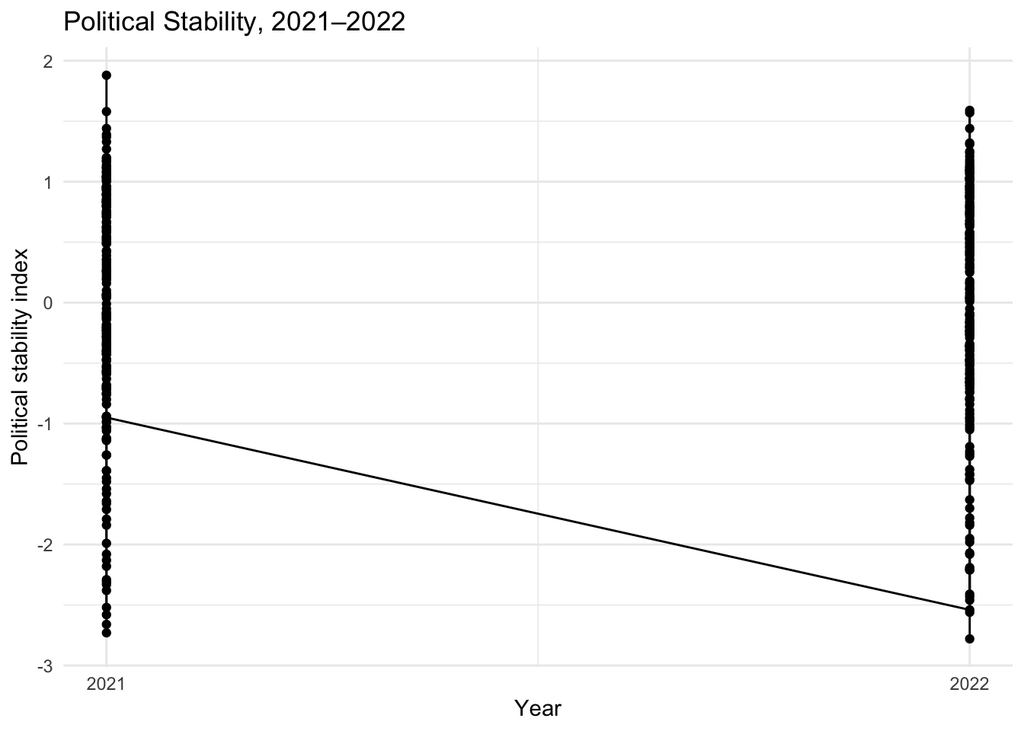

```r
ggplot(df_filtered_stability, aes(x = Year, y = value_num)) +
  geom_line() +
  geom_point() +
  scale_x_continuous(breaks = c(2021, 2022)) +
  labs(
    x = "Year",
    y = "Political stability index",
    title = "Political Stability, 2021–2022"
  ) +
  theme_minimal()
```

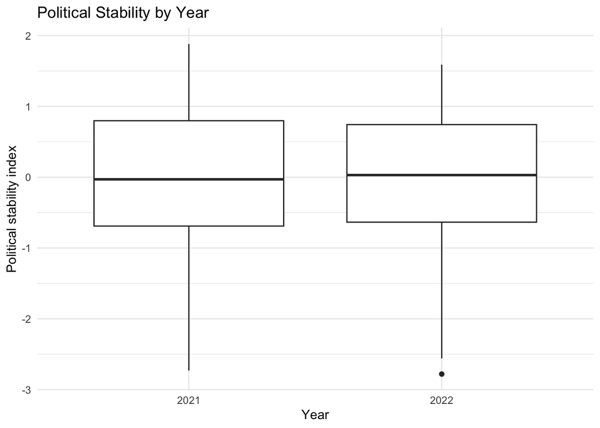

```r
#Simple box plot
ggplot(df_filtered_stability, aes(x = factor(Year), y = value_num)) +
  geom_boxplot() +
  labs(
    x = "Year",
    y = "Political stability index",
    title = "Political Stability by Year"
  ) +
  theme_minimal()
```

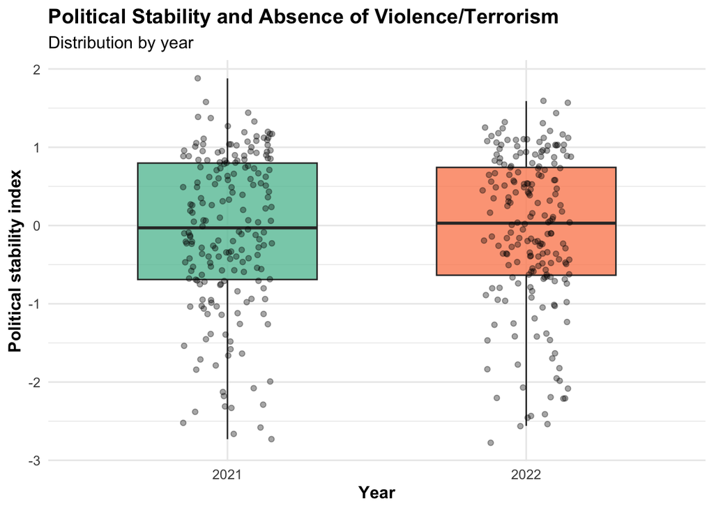

```r
#Pretty box plot
ggplot(df_filtered_stability, aes(x = factor(Year), y = value_num, fill = factor(Year))) +
  geom_boxplot(
    width = 0.6,
    alpha = 0.8,
    outlier.shape = NA
  ) +
  geom_jitter(
    width = 0.15,
    alpha = 0.35,
    size = 1.5
  ) +
  scale_fill_brewer(palette = "Set2") +
  labs(
    x = "Year",
    y = "Political stability index",
    title = "Political Stability and Absence of Violence/Terrorism",
    subtitle = "Distribution by year"
  ) +
  theme_minimal(base_size = 12) +
  theme(
    legend.position = "none",
    plot.title = element_text(face = "bold"),
    axis.title = element_text(face = "bold")
  )
```

```r
# Violing plot

temp_plot <- ggplot(df_filtered_stability, aes(x = factor(Year), y = value_num, fill = factor(Year))) +
  geom_violin(
    trim = FALSE,
    alpha = 0.8
  ) +
  geom_boxplot(
    width = 0.12,
    fill = "white",
    outlier.shape = NA
  ) +
  geom_jitter(
    width = 0.1,
    alpha = 0.3,
    size = 1.3
  ) +
  scale_fill_brewer(palette = "Set2") +
  labs(
    x = "Year",
    y = "Political stability index",
    title = "Political Stability and Absence of Violence/Terrorism",
    subtitle = "Distribution by year"
  ) +
  theme_minimal(base_size = 12) +
  theme(
    legend.position = "none",
    plot.title = element_text(face = "bold"),
    axis.title = element_text(face = "bold")
  )
```

#### Saving plots as images

```r
#Saving the plots as images
ggsave(
  filename = "political_stability_violin_2021_2022_2.png",
  plot = temp_plot,
  width = 8,
  height = 6,
  dpi = 300
)
```

### Regressions

Let’s investigate the relationship between political stability and GDP

```r
# lets see how stability and GDP compare
reg_df <- food_security_df_modified %>%
  filter(
    Item == "Political stability and absence of violence/terrorism (index)"
    |Item == "Gross domestic product per capita, PPP, (constant 2021 international $)"
    )


reg_df_years <- reg_df %>%
  filter(
    Year == 2021 | Year == 2022
  )

# Reshaping the data so we can run the regressions. Right now it's long, we need it wide (i.e. we're going to pivot the table)
df_wide <- reg_df_years %>%
  filter(Item %in% c(
    "Gross domestic product per capita, PPP, (constant 2021 international $)",
    "Political stability and absence of violence/terrorism (index)"
  )) %>%
  #making sure our values are treated as numbers
  mutate(
    Value = as.numeric(Value),     # if Value is character
    Year  = as.integer(Year)
  ) %>%
  #pivoting the table
  select(Area, Year, Item, Value) %>%
  pivot_wider(
    names_from = Item,
    values_from = Value
  ) %>%
  # renaming columns for ease of use
  rename(
    gdp = `Gross domestic product per capita, PPP, (constant 2021 international $)`,
    pol_stab   = `Political stability and absence of violence/terrorism (index)`
  ) %>%
  # getting rid of any blank values is good practice
  drop_na(gdp, pol_stab)
```

#### Running the regression

##### Raw GPD

```r
#running the regression

# Raw GDP
m1 <- lm(gdp ~ pol_stab, data = df_wide)
summary(m1)
```

```
##
## Call:
## lm(formula = gdp ~ pol_stab, data = df_wide)
##
## Residuals:
##    Min     1Q Median     3Q    Max
## -39475 -13757  -2334  10534  93768
##
## Coefficients:
##             Estimate Std. Error t value Pr(>|t|)
## (Intercept)    26106       1158   22.54   <2e-16 ***
## pol_stab       14200       1196   11.87   <2e-16 ***
## ---
## Signif. codes:  0 '***' 0.001 '**' 0.01 '*' 0.05 '.' 0.1 ' ' 1
##
## Residual standard error: 22430 on 374 degrees of freedom
## Multiple R-squared:  0.2737, Adjusted R-squared:  0.2718
## F-statistic:   141 on 1 and 374 DF,  p-value: < 2.2e-16
```

##### Log GDP, since GDP tends to skew right

```r
# Log GDP, since it tends to be sweked right
m2 <- lm(log(gdp) ~pol_stab, data= df_wide)
summary(m2)
```

```
##
## Call:
## lm(formula = log(gdp) ~ pol_stab, data = df_wide)
##
## Residuals:
##     Min      1Q  Median      3Q     Max
## -2.3856 -0.6761  0.2010  0.6945  2.0400
##
## Coefficients:
##             Estimate Std. Error t value Pr(>|t|)
## (Intercept)  9.60146    0.04899  195.99   <2e-16 ***
## pol_stab     0.69955    0.05058   13.83   <2e-16 ***
## ---
## Signif. codes:  0 '***' 0.001 '**' 0.01 '*' 0.05 '.' 0.1 ' ' 1
##
## Residual standard error: 0.9488 on 374 degrees of freedom
## Multiple R-squared:  0.3384, Adjusted R-squared:  0.3366
## F-statistic: 191.3 on 1 and 374 DF,  p-value: < 2.2e-16
```

##### Time Fixed Effects

```r
# With time fixed effects
m3 <- lm(log(gdp) ~ pol_stab + factor(Year), data = df_wide)
summary(m3)
```

```
##
## Call:
## lm(formula = log(gdp) ~ pol_stab + factor(Year), data = df_wide)
##
## Residuals:
##     Min      1Q  Median      3Q     Max
## -2.3680 -0.6812  0.2064  0.6954  2.0225
##
## Coefficients:
##                  Estimate Std. Error t value Pr(>|t|)
## (Intercept)       9.58378    0.06950 137.894   <2e-16 ***
## pol_stab          0.69959    0.05064  13.815   <2e-16 ***
## factor(Year)2022  0.03519    0.09797   0.359     0.72
## ---
## Signif. codes:  0 '***' 0.001 '**' 0.01 '*' 0.05 '.' 0.1 ' ' 1
##
## Residual standard error: 0.9499 on 373 degrees of freedom
## Multiple R-squared:  0.3386, Adjusted R-squared:  0.3351
## F-statistic: 95.48 on 2 and 373 DF,  p-value: < 2.2e-16
```

##### Controlling for Area

```r
# Controlling for area
m4 <- lm(log(gdp) ~ pol_stab + factor(Area) + factor(Year), data = df_wide)
summary(m4)
```

[output not shown]

#### Graphing Regression results

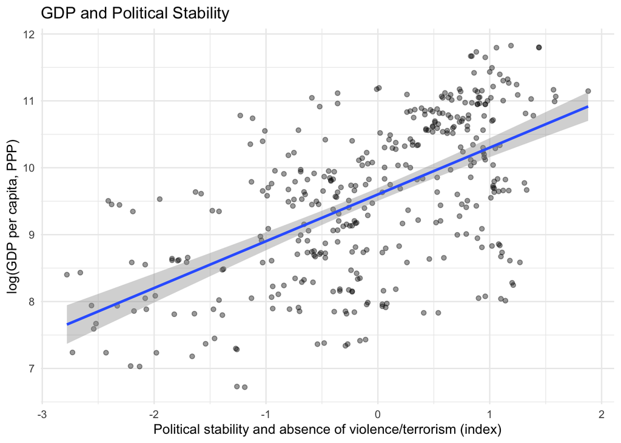

```r
ggplot(df_wide, aes(x = pol_stab, y = log(gdp))) +
  geom_point(alpha = 0.4) +
  geom_smooth(method = "lm", se = TRUE) +
  theme_minimal() +
  labs(
    x = "Political stability and absence of violence/terrorism (index)",
    y = "log(GDP per capita, PPP)",
    title = "GDP and Political Stability"
  )
```

#### Nice regression tables

```r
library(broom)
library(gt)

tidy(m1) %>%
  gt() %>%
  fmt_number(columns = c(estimate, std.error), decimals = 3) %>%
  tab_header(
    title = "Regression results",
    subtitle = "Dependent variable: GDP per capita"
  )
```

Regression results

Dependent variable: GDP per capita

| term | estimate | std.error | statistic | p.value |
| --- | --- | --- | --- | --- |
| (Intercept) | 26,105.629 | 1,158.398 | 22.53597 | 1.176300e-71 |
| pol_stab | 14,200.471 | 1,196.006 | 11.87324 | 8.254138e-28 |

```r
# Making things nicer, rounding vals
tidy(m2) %>%
  mutate(
    estimate  = round(estimate, 3),
    std.error = round(std.error, 3),
    statistic = round(statistic, 2),
    p.value   = round(p.value, 3)
  ) %>%
  gt() %>%
  fmt_number(columns = c(estimate, std.error), decimals = 2) %>%
  tab_header(
    title = "Regression results",
    subtitle = "Dependent variable: log(GDP per capita)"
  )
```

Regression results

Dependent variable: log(GDP per capita)

| term | estimate | std.error | statistic | p.value |
| --- | --- | --- | --- | --- |
| (Intercept) | 9.60 | 0.05 | 195.99 | 0 |
| pol_stab | 0.70 | 0.05 | 13.83 | 0 |

## For Future Reference

### Keyboard Shortcuts

- Make a new code chunk (Command + Option + I)
- Assign a new variable (Option + Dash)

### Code Chunk Options

| Chunk option | What it controls | Why it matters in reports | Plain-language explanation |
| --- | --- | --- | --- |
| `echo` | Whether the R code is shown | Separates analysis from presentation | Show or hide the code |
| `eval` | Whether the code is executed | Lets you display example code without running it | Run this code or not |
| `message` | Package and function messages | Keeps output clean and professional | Hide messages like “Attaching package…” |
| `warning` | Warning messages | Prevents confusing output for readers | Show or hide warnings |
| `include` | Whether code *and* results appear | Allows silent background computation | Run this but don’t show anything |
| `results` | How printed output is treated | Required for tables and formatted text | Control how output is displayed |
| `fig.width` / `fig.height` | Figure size (in inches) | Ensures readable, publication-ready figures | Control plot size |
| `fig.cap` | Figure caption text | Enables figure numbering and captions | Text shown under the figure |
| `cache` | Whether results are saved | Speeds up slow reports | Don’t re-run unless code changes |
| `error` | Behavior when errors occur | Useful for teaching and debugging | Keep knitting even if this fails |

```r
lm(y ~ x, data = df)
```

[output not shown]